# The dataset contains over 1 millions rows of housing prices from UK housing, obtained from Kaggle. I filter out missing , NA values and convert the sale amount to K notation for better visualzation in

# Spatial correlation and choose the highest sale town to predict 5 years of price

```r
file <- "real_estate.csv"

# Load the full dataset
real_estate_data_full <- read.csv(file, stringsAsFactors = FALSE)

# Clean column names for consistency
colnames(real_estate_data_full) <- gsub("\\s+", ".", colnames(real_estate_data_full))

# Check the column names
print(colnames(real_estate_data_full))
```

```
##  [1] "Date.Recorded"    "List.Year"        "Town"             "Address"
##  [5] "Assessed.Value"   "Sale.Amount"      "Sales.Ratio"      "Property.Type"
##  [9] "Residential.Type" "Longitude"        "Latitude"
```

```r
# Create a subset with relevant columns (include Town)
real_estate_data <- real_estate_data_full %>%
  filter(!is.na(Date.Recorded) & !is.na(Sale.Amount) & Sale.Amount > 0) %>%
  select(Date.Recorded, Sale.Amount, Sales.Ratio, Property.Type, Residential.Type, Town, Longitude, Latitude)

# Convert Sale.Amount to k
real_estate_data$Sale.Amount <- real_estate_data$Sale.Amount / 1000

# Ensure Date.Recorded is in correct date format
real_estate_data$Date.Recorded <- as.Date(real_estate_data$Date.Recorded)

# Create YearMonth as YYYY-MM
real_estate_data$YearMonth <- format(real_estate_data$Date.Recorded, "%Y-%m")

# Filter out any empty YearMonth
real_estate_data <- real_estate_data %>%
  filter(!is.na(YearMonth), YearMonth != "")

# Aggregate by town and month
town_month_data <- real_estate_data %>%
  group_by(Town, YearMonth) %>%
  summarise(Avg_Sale_Amount = mean(Sale.Amount, na.rm = TRUE), .groups = "drop")
```

# There are so many missing, NAn, or Na data values in the longitude and latitude so i have to filter out these missing values.

```r
# Get unique town coordinates (average lat/lon per town)
town_coords <- real_estate_data %>%
  group_by(Town) %>%
  summarise(Town_Lat = mean(Latitude, na.rm = TRUE),
            Town_Lon = mean(Longitude, na.rm = TRUE),
            .groups = "drop")

# Join coordinates to town-month data
town_month_data <- left_join(town_month_data, town_coords, by = "Town")
```

```r
# Remove any rows with missing coordinates
town_month_data <- town_month_data %>%
  filter(!is.na(Town_Lon), !is.na(Town_Lat))

# Create a Wide format for Differencing
unique_months <- sort(unique(town_month_data$YearMonth))

town_wide <- town_month_data %>%
  select(Town, YearMonth, Avg_Sale_Amount) %>%
  pivot_wider(id_cols = Town, names_from = YearMonth, values_from = Avg_Sale_Amount)

# Ensure columns are sorted by date
town_wide <- town_wide[, c("Town", unique_months)]
```

```r
town_wide_diff <- town_wide
diff_matrix <- t(apply(town_wide_diff[, -1], 1, function(x) diff(x, lag = 1)))
diff_months <- unique_months[-1]
town_wide_diff <- data.frame(Town = town_wide$Town, diff_matrix)
colnames(town_wide_diff) <- c("Town", diff_months)

# Compute average differenced price per town
diff_averages <- town_wide_diff %>%
  rowwise() %>%
  mutate(Avg_Diff_Price = mean(c_across(where(is.numeric)), na.rm = TRUE)) %>%
  ungroup() %>%
  select(Town, Avg_Diff_Price)

diff_averages <- diff_averages %>% filter(!is.na(Avg_Diff_Price))
```

# I want to understand the correlation of town and the price to choose the best or highest price town and make the prediction or forecasting price of 5 years based on that.

```r
# Spatial correlation
town_sf <- left_join(town_coords, diff_averages, by = "Town") %>%
  filter(!is.na(Avg_Diff_Price), !is.na(Town_Lon), !is.na(Town_Lat))

town_sf <- st_as_sf(town_sf, coords = c("Town_Lon", "Town_Lat"), crs = 4326)

# k-nearest neighbors
coords <- st_coordinates(town_sf)
knn <- knearneigh(coords, k = 5)
nb_knn <- knn2nb(knn)
lw_knn <- nb2listw(nb_knn, style = "W")

moran_result <- moran.test(town_sf$Avg_Diff_Price, lw_knn)
print(moran_result)
```

```
##
##  Moran I test under randomisation
##
## data:  town_sf$Avg_Diff_Price
## weights: lw_knn
##
## Moran I statistic standard deviate = -0.9792, p-value = 0.8363
## alternative hypothesis: greater
## sample estimates:
## Moran I statistic       Expectation          Variance
##      -0.045819358      -0.005952381       0.001657624
```

# Since the p value is much greater than 0.05, the model fails to reject the null hypothesis of no spatial autocorrelation. Thus there is no significant spatial correlation.

```r
# Select the Highest-Priced town
diff_averages <- diff_averages %>% arrange(desc(Avg_Diff_Price))
top_town <- diff_averages$Town[1]
cat("The highest priced town is:", top_town, "\n")
```

```
## The highest priced town is: Deep River
```

```r
# Forecasting for the selested town with the best SARIMA
selected_town_data <- town_month_data %>%
  filter(Town == top_town) %>%
  arrange(YearMonth)

selected_town_data$Date <- as.Date(paste0(selected_town_data$YearMonth, "-01"))

start_year <- as.numeric(format(min(selected_town_data$Date), "%Y"))
start_month <- as.numeric(format(min(selected_town_data$Date), "%m"))
town_ts <- ts(selected_town_data$Avg_Sale_Amount, start = c(start_year, start_month), frequency = 12)

# ARIMA(1,1,2)(0,1,1)[12]
best_sarima_model <- Arima(
  town_ts,
  order = c(1, 1, 2),
  seasonal = list(order = c(0, 1, 1), period = 12),
  method = "ML"
)
summary(best_sarima_model)
```

```
## Series: town_ts
## ARIMA(1,1,2)(0,1,1)[12]
##
## Coefficients:
##           ar1      ma1      ma2     sma1
##       -0.2475  -0.7640  -0.2115  -1.0000
## s.e.   1.0073   1.0107   0.9952   0.1064
##
## sigma^2 = 35910:  log likelihood = -1203.47
## AIC=2416.94   AICc=2417.29   BIC=2432.85
##
## Training set error measures:
##                     ME     RMSE      MAE       MPE     MAPE      MASE
## Training set -10.47273 180.8708 94.65666 -21.35343 36.67157 0.7274521
##                      ACF1
## Training set -0.006181827
```

# I forecast the next 5 years or 60 months using different color like red and gray and blue such that red is predicting price for 5 years while gray is confident interval and blue is from the original data values.

```r
# Forecast for the next 60 months
horizon <- 60
town_forecast <- forecast(best_sarima_model, h = horizon)

# Create a data frame for the forecast
future_dates <- seq(
  from = tail(selected_town_data$Date, 1) %m+% months(1),
  by = "month",
  length.out = horizon
)

forecast_df <- data.frame(
  Date = future_dates,
  Forecast = as.numeric(town_forecast$mean),
  Lower80 = as.numeric(town_forecast$lower[,1]),
  Upper80 = as.numeric(town_forecast$upper[,1]),
  Lower95 = as.numeric(town_forecast$lower[,2]),
  Upper95 = as.numeric(town_forecast$upper[,2])
)
```

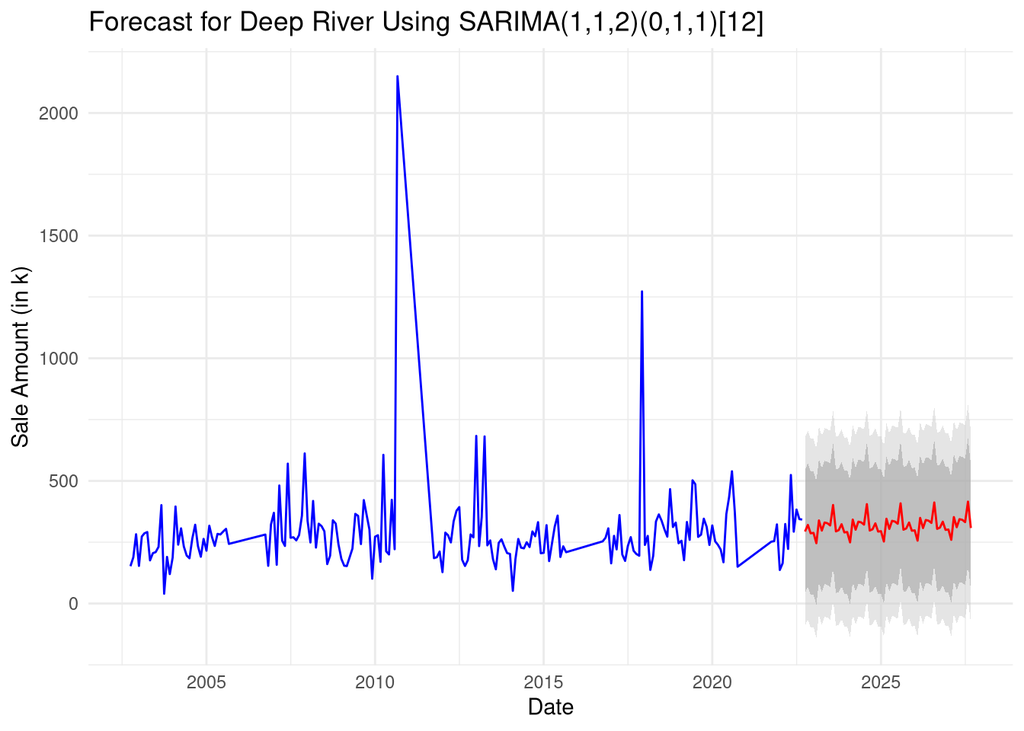

```r
# Plot the historical data and the forecast on the original scale
ggplot() +
  # Historical data
  geom_line(data = selected_town_data, aes(x = Date, y = Avg_Sale_Amount), color = "blue") +

  # 95% interval
  geom_ribbon(data = forecast_df, aes(x = Date, ymin = Lower95, ymax = Upper95), fill = "gray80", alpha = 0.5) +
  # 80% interval
  geom_ribbon(data = forecast_df, aes(x = Date, ymin = Lower80, ymax = Upper80), fill = "gray60", alpha = 0.5) +

  # Forecast line
  geom_line(data = forecast_df, aes(x = Date, y = Forecast), color = "red") +

  labs(title = paste("Forecast for", top_town, "Using SARIMA(1,1,2)(0,1,1)[12]"),
       x = "Date", y = "Sale Amount (in k)") +
  theme_minimal()
```

# The result shows Deep River town price forecasting for 5 years of upto 500k pounds

```r
# Aggregate data by Residential Type and Month
residential_data <- real_estate_data %>%
  group_by(Residential.Type, YearMonth) %>%
  summarise(
    Avg_Sale_Amount = mean(Sale.Amount, na.rm = TRUE),
    Transaction_Count = n(),
    .groups = "drop"
  )

# Inspect the aggregated data
print(head(residential_data))
```

```
## # A tibble: 6 × 4
##   Residential.Type YearMonth Avg_Sale_Amount Transaction_Count
##   <chr>            <chr>               <dbl>             <int>
## 1 ""               2001-10              220.              5164
## 2 ""               2001-11              232.              4257
## 3 ""               2001-12              227.              4635
## 4 ""               2002-01              239.              4002
## 5 ""               2002-02              239.              3426
## 6 ""               2002-03              245.              4210
```

```r
# Aggregate by Residential Type and Location (Latitude and Longitude)
residential_coords <- real_estate_data %>%
  group_by(Residential.Type) %>%
  summarise(
    Avg_Sale_Amount = mean(Sale.Amount, na.rm = TRUE),
    Avg_Latitude = mean(Latitude, na.rm = TRUE),
    Avg_Longitude = mean(Longitude, na.rm = TRUE),
    .groups = "drop"
  )

# Convert to spatial data
residential_sf <- st_as_sf(residential_coords, coords = c("Avg_Longitude", "Avg_Latitude"), crs = 4326)

# k-nearest neighbors for spatial correlation
coords <- st_coordinates(residential_sf)
knn <- knearneigh(coords, k = 5)
nb_knn <- knn2nb(knn)
lw_knn <- nb2listw(nb_knn, style = "W")

# Moran's I for Avg_Sale_Amount by Residential Type
moran_result_residential <- moran.test(residential_sf$Avg_Sale_Amount, lw_knn)
print(moran_result_residential)
```

```
##
##  Moran I test under randomisation
##
## data:  residential_sf$Avg_Sale_Amount
## weights: lw_knn
##
## Moran I statistic standard deviate = 3.9825e-09, p-value = 0.5
## alternative hypothesis: greater
## sample estimates:
## Moran I statistic       Expectation          Variance
##     -2.000000e-01     -2.000000e-01      4.857226e-17
```